# Analysis of simulations

Tim B

7/1/2021

## Exploratory simulation studies

This writeup examines some of the exploratory `glmeiv` simulations. First, we load the package `simulatr`. In addition to helping power the simulations, `simulatr` provides some functions to summarize and plot simulation study results.

```r
library(simulatr)
library(magrittr)
```

## Simulation study 1: No covariates

We examine the results of the first simulation study. We load the `simulatr_specifier` object, which contains the full specification of the simulation, as well as the raw simulation results outputted by `simulatr`.

```r
sim_dir <- paste0(.get_config_path("LOCAL_GLMEIV_DATA_DIR"), "private/simulations")
sim_spec <- readRDS(paste0(sim_dir, "/sim_spec_1.rds")) # simulatr specifier object
sim_res <- readRDS(paste0(sim_dir, "/raw_result_1.rds")) # raw results
```

This simulation study has three “arms”: one in which `pi` is varied, one in which `m_perturbation` is varied, and one in which `g_perturbation` is varied. The parameters `n = 2000` (number of cells), `m_intercept = 1`, and `g_intercept = -2` are fixed. We use Poisson GLMs to model both the mRNA and gRNA counts. Finally, we use `B=2000` replicates for each parameter setting.

Below, we print the parameter grid and fixed parameters. Note that the parameter grid contains additional columns identifying the “arm” or “arms” to which a parameter setting belongs.

```r
sim_spec@parameter_grid
```

```
##      pi m_perturbation g_perturbation arm_pi arm_m_perturbation arm_g_perturbation
## 1  0.05           -2.0           3.00   TRUE              FALSE              FALSE
## 2  0.10           -2.0           3.00   TRUE              FALSE              FALSE
## 3  0.15           -2.0           3.00   TRUE              FALSE              FALSE
## 4  0.20           -2.0           3.00   TRUE              FALSE              FALSE
## 5  0.25           -2.0           3.00   TRUE               TRUE               TRUE
## 6  0.30           -2.0           3.00   TRUE              FALSE              FALSE
## 7  0.35           -2.0           3.00   TRUE              FALSE              FALSE
## 8  0.40           -2.0           3.00   TRUE              FALSE              FALSE
## 9  0.45           -2.0           3.00   TRUE              FALSE              FALSE
## 10 0.50           -2.0           3.00   TRUE              FALSE              FALSE
## 11 0.25            0.0           3.00  FALSE               TRUE              FALSE
## 12 0.25           -0.2           3.00  FALSE               TRUE              FALSE
## 13 0.25           -0.4           3.00  FALSE               TRUE              FALSE
## 14 0.25           -0.6           3.00  FALSE               TRUE              FALSE
```

[output cut: 18 more lines]

```r
sim_spec@fixed_parameters
```

```
## $seed
## [1] 4
##
## $n
## [1] 2000
##
## $B
## [1] 2000
##
## $n_processors
## [1] 10
##
## $m_intercept
## [1] 1
##
## $g_intercept
## [1] -2
##
## $m_fam
##
## Family: poisson
## Link function: log
##
##
## $g_fam
##
## Family: poisson
## Link function: log
##
##
## $alpha
## [1] 0.95
##
## $n_em_rep
## [1] 5
##
## $p_flip
## [1] 0.01
##
## $m_covariate_coefs
## NULL
##
## $g_covariate_coefs
## NULL
##
## $covariate_matrix
## NULL
##
## $m_offset
## NULL
##
## $g_offset
## NULL
```

```r
summarized_results <- summarize_results(sim_spec = sim_spec,
                                        sim_res = sim_res,
                                        metrics = c("coverage", "bias", "rejection_probability"),
                                        parameters = c("m_perturbation"))
```

Next, we plot the results, comparing the EM method to the thresholding method.

**Bias in estimating `m_perturbation`**:

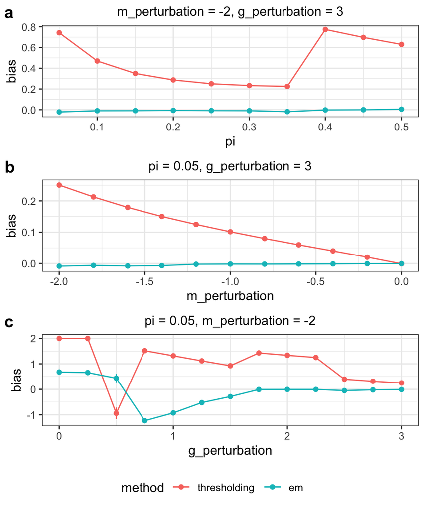

```r
plot_all_arms(summarized_results = summarized_results,
              metric = "bias",
              parameter = "m_perturbation")
```

**Rejection probability for `m_perturbation`**:

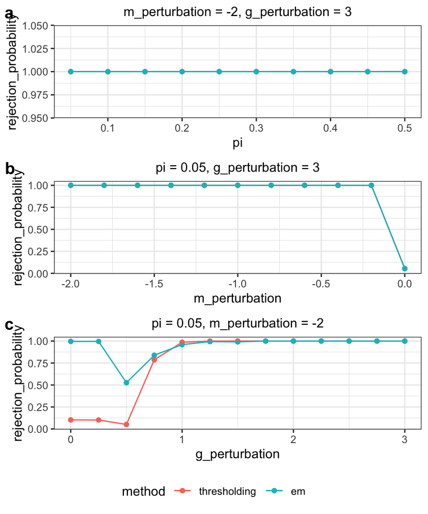

```r
plot_all_arms(summarized_results = summarized_results,
              metric = "rejection_probability",
              parameter = "m_perturbation")
```

**Confidence interval coverage rate for `m_perturbation`**:

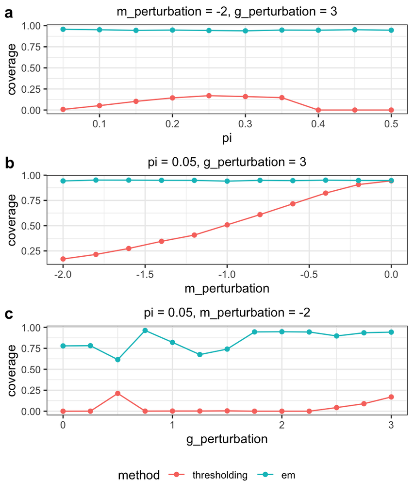

```r
plot_all_arms(summarized_results = summarized_results,
              metric = "coverage",
              parameter = "m_perturbation")
```

The EM method is less biased than the thresholding method.